# Probability Practice

Zackary Scalyer

9/22/2020

Wackerly, D., Mendenhall, W., & Scheaffer, R. L. (2014). *Mathematical statistics with applications*. Cengage Learning.

## Exercise 3.1 p. 90

> When the health department tested private wells in a count for two impurities commonly found in drinking water, it found that 20% of the wells had neither impurity, 40% had impurity A, and 50% had impurity B. If a well is randomly chosen from those in the county, find the probability distribution for $Y$, the number of impurities found in the well.

### Your Turn

Recall, De Morgan’s laws

$$\overline{\{A \cap B\}} = \overline{A} \cup \overline{B}$$

$$\overline{\{A \cup B\}} = \overline{A} \cap \overline{B}$$

### Soln

The sample space is the collection of simple events $\{0,1,2\}$

Let $Y$ be a random varable that can take the values $y = \{0,1,2\}$

*Note: $Y$ represents the sample space of our experiment as a random variable, and $y$ represents a sample of the experiment as an observed value of the random variable.*

We want the probability distrabution for $Y$

$p_Y(y) = Pr(Y=y)$ is a real-valued function for the random varable Y that can take the values $y = \{0,1,2\}$

Where,

$y = 0$ is the event $\{\overline{A} \cap \overline{B}\}$ nether A and no B impurities found.

$y = 1$ is the event $\{\overline{A} \cap B\} \cup \{\overline{B} \cap A\}$ one impurity found.

$y = 2$ is the event $\{A \cap B\}$ two impurities found.

Since 20% of the wells had neither impurity

$p_Y(0) =Pr(Y=0) = 0.2$ there is a 20% chance that a random well does not have impurities

using De Morgan’s law and the propertie of a complament event probability

$Pr(\overline{A} \cap \overline{B}) = Pr(\overline{\{A \cup B\}}) = 1 - Pr(A \cup B) = 20\%$

we have,

$Pr(A \cup B) = 1 - 0.2 = 0.8$

another propertie of probability

$Pr(A \cup B) = Pr(A) + Pr(B) - Pr(A \cap B)$

$0.8 = 0.4 + 0.5 - Pr(A \cap B)$

returns

$Pr(A \cap B) = 0.1$ the probibility of finding two impurities in a random well

What is the probibility of finding one impuritie?

$Pr(\{\overline{A} \cap B\} \cup \{\overline{B} \cap A\}) = Pr(\overline{A} \cap B) + Pr(\overline{B} \cap A)\\ \quad\quad\quad\quad\quad\quad\quad\quad\quad\quad\;\,= Pr(B) - Pr(A \cap B) + Pr(A) - Pr(A \cap B)\\ \quad\quad\quad\quad\quad\quad\quad\quad\quad\quad\;\,= 0.5 + 0.4 - 2 \times 0.1\\ \quad\quad\quad\quad\quad\quad\quad\quad\quad\quad\;\, = 0.7$

Therefore, the probability distrabution for the discrete random varable

| $Y = y$ | $Pr(Y = y)$ |
| --- | --- |
| 0 | 0.2 |
| 1 | 0.7 |
| 2 | 0.1 |

### PDF plot

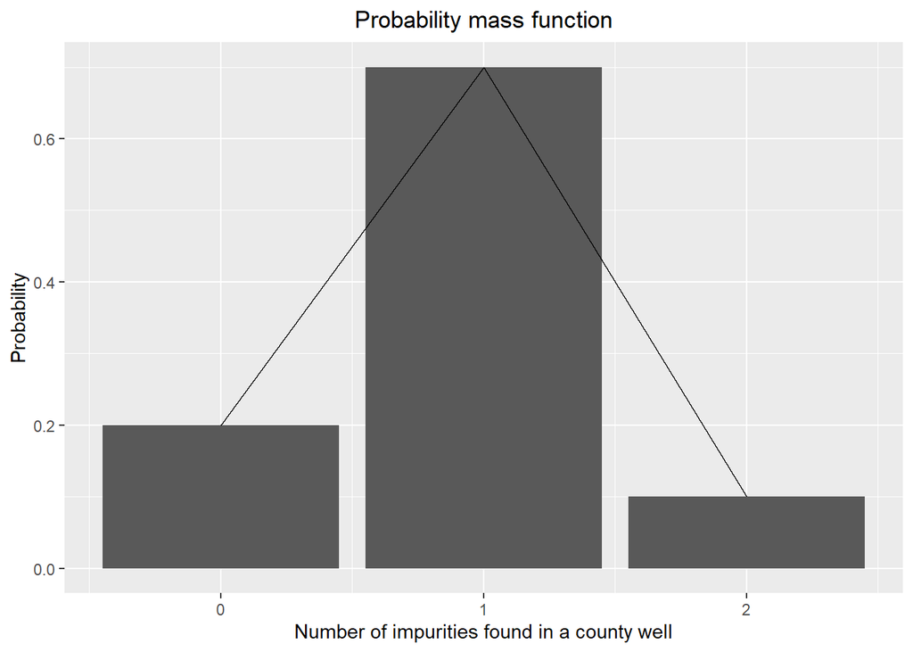

```r
pdf.Y <- function(y){
  if (y == 0){
    return(0.2)
  } else if (y == 1){
    return(0.7)
  } else if (y == 2){
    return(0.1)
  } else{
    return(0)
  }
}

data.frame(Y = 0:2,
           Pr = map_dbl(0:2, pdf.Y)) %>%
  ggplot(aes(Y,Pr)) +
  geom_col() +
  geom_path() +
  labs(title = "Probability mass function",
       x = "Number of impurities found in a county well",
       y = "Probability") +
  theme(plot.title = element_text(hjust = 0.5))
```

### Simulated distrbution with pdf

```r
sample(x = 0:2, size = 1,
       replace = TRUE,
       prob = map_dbl(0:2, ~pdf.Y(y = .))) # one observation, y
```

```
## [1] 1
```

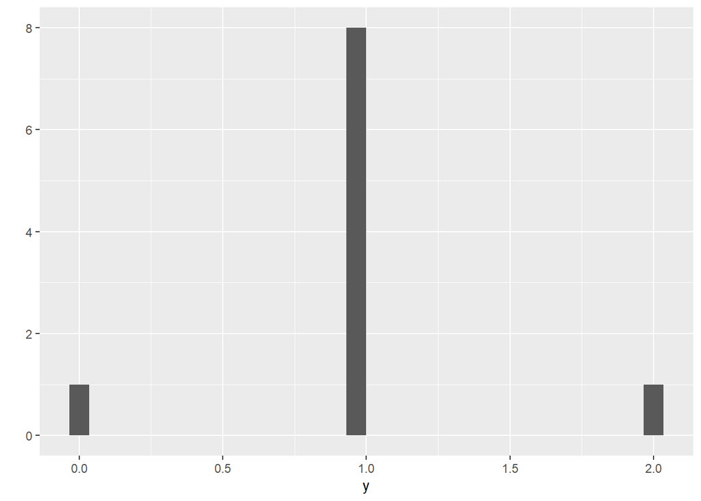

```r
n = 10 # sample size of 10
data.frame(y = sample(x = 0:2, size = n, replace = TRUE,
                      prob = map_dbl(0:2, ~pdf.Y(y = .)))) %>%
  qplot(x = y, data = .)
```

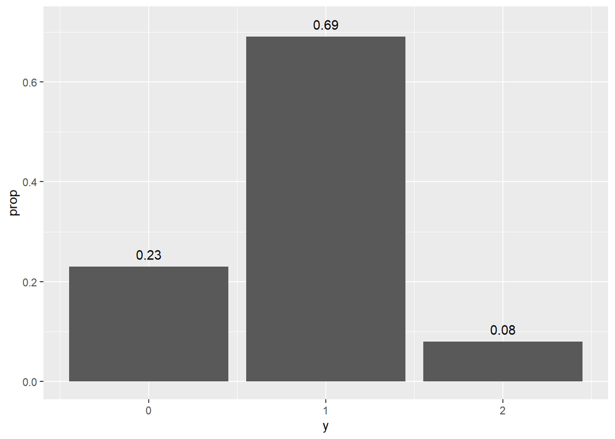

```r
n = 100 # sample size of 10
data.frame(y = sample(x = 0:2, size = n, replace = TRUE,
                      prob = map_dbl(0:2, ~pdf.Y(y = .)))) %>%
  ggplot(aes(x = y, y = ..prop..)) +
  geom_bar(stat = "count") +
  geom_text(stat = "count", aes(label = ..prop..),
            nudge_y = 0.025)
```

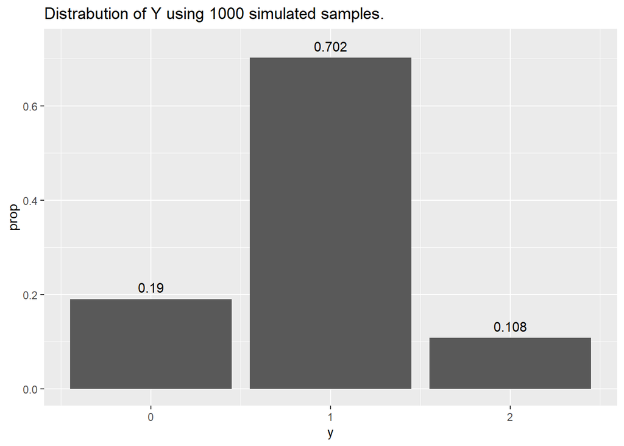

```r
n = 1000 # sample size of 10
data.frame(y = sample(x = 0:2, size = n, replace = TRUE,
                      prob = map_dbl(0:2, ~pdf.Y(y = .)))) %>%
  ggplot(aes(x = y, y = ..prop..)) +
  geom_bar(stat = "count") +
  geom_text(stat = "count", aes(label = ..prop..),
            nudge_y = 0.025) +
  labs(title = paste0("Distrabution of Y using ", n, " simulated samples."))
```